# Project Company

George.B

2022-12-19

# Summary

##### project.

- Electric Vehicle(E.V) that has a total distance of over 220 and their Models.
- Company with the highest number of E.v since the invention of E.V.
- Number E.v that runs on Battery to those that are Plug_in Hybrid.
- This data and it’s findings are all based in USA.

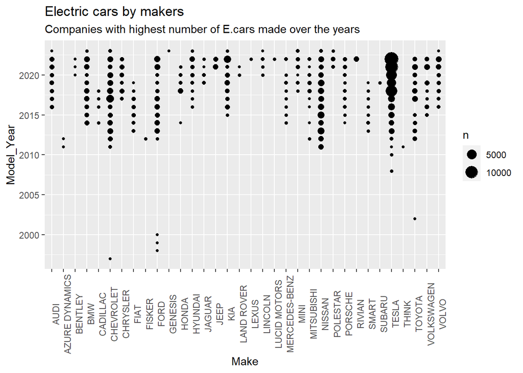

- The viz above shows the Companies with highest E.V made and the years this Vehicles were made.
- Tesla has the largest amount of E.V’s made among others, starting from 2018 up to 2022.

```
## # A tibble: 30 × 6
## # Groups:   Electric_Range, Model_Year, Make, Model, Electric_Vehicle_Type [30]
##    Electric_Range Model_Year Make      Model    Electric_Vehicle_Type    Clean…¹
##             <dbl>      <dbl> <chr>     <chr>    <chr>                    <chr>
##  1            220       2008 TESLA     ROADSTER Battery Electric Vehicl… Clean …
##  2            220       2017 TESLA     MODEL 3  Battery Electric Vehicl… Clean …
##  3            220       2019 TESLA     MODEL 3  Battery Electric Vehicl… Clean …
##  4            222       2021 AUDI      E-TRON   Battery Electric Vehicl… Clean …
##  5            233       2021 POLESTAR  PS2      Battery Electric Vehicl… Clean …
##  6            234       2019 JAGUAR    I-PACE   Battery Electric Vehicl… Clean …
##  7            234       2020 JAGUAR    I-PACE   Battery Electric Vehicl… Clean …
##  8            238       2017 CHEVROLET BOLT EV  Battery Electric Vehicl… Clean …
##  9            238       2018 CHEVROLET BOLT EV  Battery Electric Vehicl… Clean …
## 10            238       2018 TESLA     MODEL X  Battery Electric Vehicl… Clean …
## # … with 20 more rows, and abbreviated variable name
## #   ¹Clean_Alternative_Fuel_Vehicle_Eligibility
```

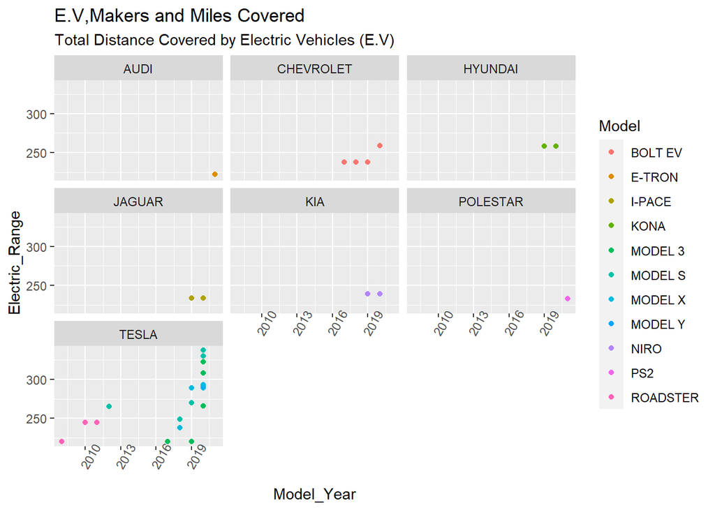

- the chart above shows E.V that covers a distance of above 220 miles.
- Tesla has the only E.V that covers a distance above 300 mile in total, with it’s 2020 Model 3 covering a distance of 308 to 322 miles in total, while it 2020 Model S cover a distance above 330 to 337 miles in total.
- All this E.V are all powered by Battery Electric Vehicles(BEV) and not Plug-in Hybrid Electric Vehicle(PHEV).

```
## # A tibble: 5 × 6
## # Groups:   Model_Year, Electric_Range, Make, Model, Electric_Vehicle_Type [5]
##   Model_Year Electric_Range Make      Model       Electric_Vehicle_Type  Clean…¹
##        <dbl>          <dbl> <chr>     <chr>       <chr>                  <chr>
## 1       1997             39 CHEVROLET S-10 PICKUP Battery Electric Vehi… Clean …
## 2       1998             58 FORD      RANGER      Battery Electric Vehi… Clean …
## 3       1999             74 FORD      RANGER      Battery Electric Vehi… Clean …
## 4       2000             58 FORD      RANGER      Battery Electric Vehi… Clean …
## 5       2002             95 TOYOTA    RAV4        Battery Electric Vehi… Clean …
## # … with abbreviated variable name ¹Clean_Alternative_Fuel_Vehicle_Eligibility
```

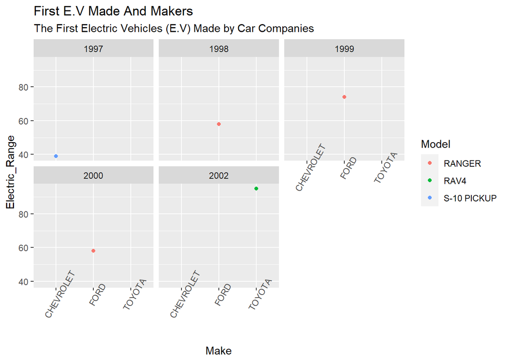

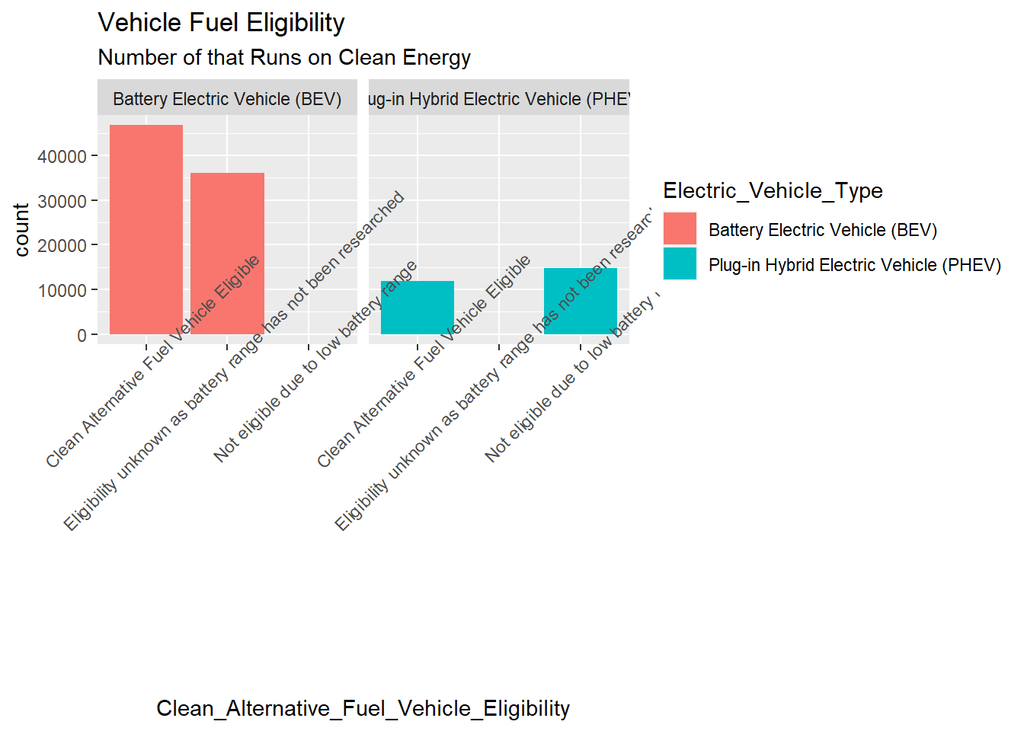

- the chart above show the Eligibility and E.V that runs on clean alternative, not eligible due to low battery and those that have not yet been researched on.
- on the Battery Electric Vehicle(BEV) the number of E.vehicles fueled clean alternative are above 45,000, while those that have not yet been researched on is above 35,000 E.V in USA.
- while those E.V powered by Plug-in Hybrid Electric vehicle(PHEV), the number of E.V that runs on clean alternative are above 10,000 and those on not eligible due to low battery are close to 15,000 in USA.

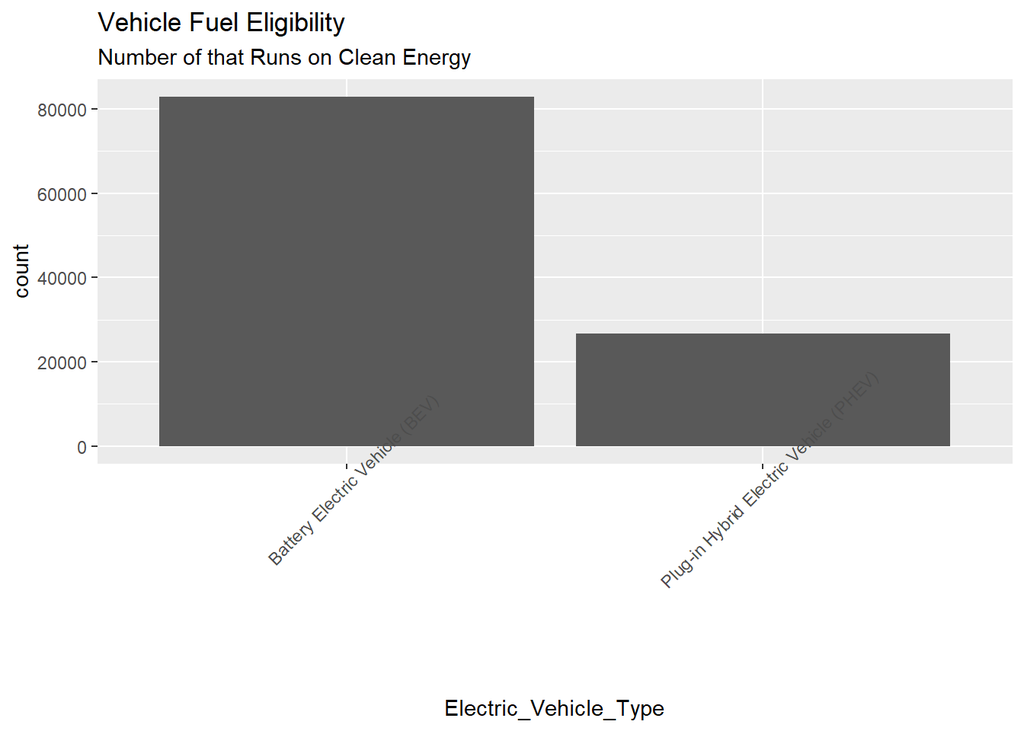